# Categorical Data Analysis Notebook 1 - Binomial and Poisson

### Zadanie 9.

Wiadomo, ˙ze dla pewnej zmiennej losowej X P(X = k) = [równanie które można zobaczyć w pdfie] Przedstawi´c rozk lad tej zmiennej graficznie, obliczy´c P (X ˇ 3) i P (X = 2). Obliczy´c warto´s´c oczekiwan ,a, wariancj,e oraz odchylenie standardowe zmiennej losowej X.

```r
attempts = 6
probability = 0.2

# P(X >= 3) - probability that there will be at least 3 (more than 2) successes
1 - pbinom((3-1), size = attempts, prob = probability)
```

```
[1] 0.09888
```

```r
# "at least 3" so 2-1


# P(X = 2)
dbinom(2,size = attempts, prob = probability)
```

```
[1] 0.24576
```

### Zadanie 10.

W pewnym towarzystwie ubezpieczeniowym 5% wszystkich zg laszanych szk´od stanowi ,a wypadki samochodowe. Jakie jest prawdopodobie´nstwo, ˙ze w´sr´od zg loszonych 15 szk´od liczba wypadk´ow samochodowych b ,edzie wi,eksza ni˙z 3.

```r
attempts = 15
car_p = 0.05

# P(X > 3) - probability that more than 3 cases (at least 4 cases) are going to be car accidents
1 - pbinom(3, size = attempts, prob = car_p)
```

```
[1] 0.005467259
```

### Zadanie 11.

W pewnym salonie Opla sprzedaje si,e w ci ,agu miesi ,aca ´srednio 5 samochod´ow tej marki. Jakie jest prawdopodobie´nstwo, ˙ze w miesi ,acu sprzedaneb,ed , co najwy˙zej 2 auta.

```r
ppois(2, lambda=5) # lambda is the expected value
```

```
[1] 0.124652
```

### Zadanie 12.

Liczb,e dni opuszczonych przez student´ow w listopadzie w wylosowanej pr´obie 250 student´ow charakteryzuje poni˙zszy szereg rozdzielczy:

```r
days_missed <- c(0, 1, 2, 3, 4, 5)
students_amount <- c(30, 110, 50, 40, 15, 5)
d <- data.frame(days=days_missed,students=students_amount)
d
```

| days | students |
| --- | --- |
| 0 | 30 |
| 1 | 110 |
| 2 | 50 |
| 3 | 40 |
| 4 | 15 |
| 5 | 5 |

```r
sum(students_amount)
```

```
[1] 250
```

```r
lam <- weighted.mean(d$days,d$students) # Expected value E(X) so it's lambda
print("Teoretyczne")
```

```
[1] "Teoretyczne"
```

```r
ceiling(ppois(0,lam) * sum(students_amount))
```

```
[1] 48
```

```r
ceiling(ppois(1,lam) * sum(students_amount)-ppois(0,lam) * sum(students_amount))
```

```
[1] 79
```

```r
ceiling(ppois(2,lam) * sum(students_amount)-ppois(1,lam) * sum(students_amount))
```

```
[1] 66
```

```r
ceiling(ppois(3,lam) * sum(students_amount)-ppois(2,lam) * sum(students_amount))
```

```
[1] 37
```

```r
ceiling(ppois(4,lam) * sum(students_amount)-ppois(3,lam) * sum(students_amount))
```

```
[1] 16
```

```r
ceiling(ppois(5,lam) * sum(students_amount)-ppois(4,lam) * sum(students_amount))
```

```
[1] 5
```

```r
ceiling(ppois(6,lam) * sum(students_amount)-ppois(5,lam) * sum(students_amount))
```

```
[1] 2
```

```r
for (i in 0:6) {
  ceiling(ppois(i,lam) * sum(students_amount)-ppois(i-1,lam) * sum(students_amount))
}
#theory
```

1. Zak ladaj ,ac, ˙ze liczba dni opuszczonych na uczelni w ci ,agu miesi ,aca podlega rozk ladowi Poissona, ustal liczebno´sci teoretyczne.
2. Oblicz prawdopodobie´nstwo, ˙ze studenci opuszczaj ,a minimum dwa dni, a maksimum 4 dni zaj,e´c.

### Zadania 13.

Pewien m lody matematyk pisz ,acy swoje artyku ly w programie LATEX stwierdzi l, ˙ze pope lnia ´srednio 4 liter´owki na jedn ,a stron,e. Wybieramy losowo jedn ,a z wielu stron napisanych przez tego matematyka. Jakie jest prawdopodobie´nstwo, ˙ze znajdziemy na niej co najwy˙zej 3 b l,edy.

```r
lam = 4
errors = 3

# 3 or less means that we want the LOWER TAIL of the function (it's the default setting)
ppois(errors, lambda = lam, lower.tail = TRUE)
```

[output not shown]

### Zadania 14.

Zmienna losowa X ma rozk lad Poissona z warto´sci ,a oczekiwan ,a r´own ,a 3. Wyznaczy´c P (X <= 6) oraz P (X >= 3)

```r
lam = 3

# P(X <= 6)
ppois(6, lambda = lam, lower.tail = TRUE) # at MOST 6 (less than 7)

# P(X >= 3)
ppois((3-1), lambda = lam, lower.tail = FALSE) # at LEAST 3 (more than 2)
```

[output not shown]

### Zadanie 15

Dla pewnej zmiennej losowej X o rozk ladzie Poissona zachodzi warunek P (X = 0) = 0.2. Znale´z´c parametry rozk ladu tej zmiennej.

```r
# P(X=0) = 0.2
# k = x, ppois = 0.2
# [e^(-lambda)  * lambda^k] / k!
# so:
# [e^(-lambda) * lambda^0] / 0! = 0.2
# [e^(-lambda) * 1] / 1 = 0.2
# e^(-lambda) = 0.2
# -log(0.2) = lambda
-log(0.2)
```

```
[1] 1.609438
```

### Zadanie 16

Zmienna losowa X ma rozk lad okre´slony wed lug nast,epuj ,acej funkcji [takiej z lambdą = 4] Wyznaczy´c warto´s´c oczekiwan ,a i odchylenie standardowe tak zdefiniowanej zmiennej losowej oraz wyznaczy´c prawdopodobie´nstwo, ˙ze zmienna losowa: (a) przyjmie warto´s´c r´own ,a 1; (b) przyjmie warto´s´c nie wi,eksz ,a ni˙z 3; (c) przyjmie warto´s´c powy˙zej 5.

**a.**

```r
lam = 4
#E(X)
lam
```

```
[1] 4
```

```r
#Var(X)
lam
```

```
[1] 4
```

```r
dpois(1,lam)
```

```
[1] 0.07326256
```

**b.**

```r
ppois(3, lam)
```

```
[1] 0.4334701
```

```r
ppois(5, lam, lower.tail = FALSE ) # more than 5 (so at least 6)
```

```
[1] 0.2148696
```

### Zadanie 17

Liczba wypadk´ow samochodowych w ci ,agu dnia w pewnym mie´sciema rozk lad Poissona o warto´sci oczekiwanej wynosz ,acej ⁄ = 2. Znale´z´c prawdopodobie´nstwo, ˙ze w ci ,agu dnia w ty mie´scie b ,ed ,a mia ly miejsce co najwy˙zej 4 wypadki samochodowe.

```r
lam = 2
ppois(4, lam)
```

```
[1] 0.947347
```

### Zadanie 18

**a.**

```r
ppois(2,lam)
```

```
[1] 0.6766764
```

**b.**

```r
lam = 4
ppois(5,lam,lower.tail = FALSE)
```

```
[1] 0.2148696
```

**c.**

```r
dpois(2,lam)
```

```
[1] 0.1465251
```

### Zadanie 19

W sk lad pewnej skomplikowanej aparatury wchodzi 150 element´owokre´slonego rodzaju. Prawdopodobie´nstwo uszkodzenia w ci ,agu rokuka˙zdego z tych element´ow jest r´owne 0,004 i nie zale˙zy od stanu pozosta lych element´ow. Obliczy´cprawdopodobie´nstwo uszkodzenia w ci , agu roku nie mniej ni˙z dw´och element´ow.

```r
k = 150
prob = 0.004
# [e^(-lambda)  * lambda^k] / k!
# [e^(-lambda) * lambda^1] / 1! = 0.004
# e^(-lambda) * lambda = 0.004
# lambda * e^(-lambda) = 0.004
lam = 8.1

ppois(2, lam)
```

```
[1] 0.01271981
```

### Zadanie 20

Zadanie 20. Za l´o˙zmy, ˙ze pewna zmienna losowa X ma rozk lad Poissona z parametrem ⁄. Sporz , ad´z wykres rozk ladu prawdopodobie´nstwa zmiennej losowej X w zale˙zno´sci od warto´sci parametru ⁄. Przyjmij ⁄ = 2, 5, 8, 10.

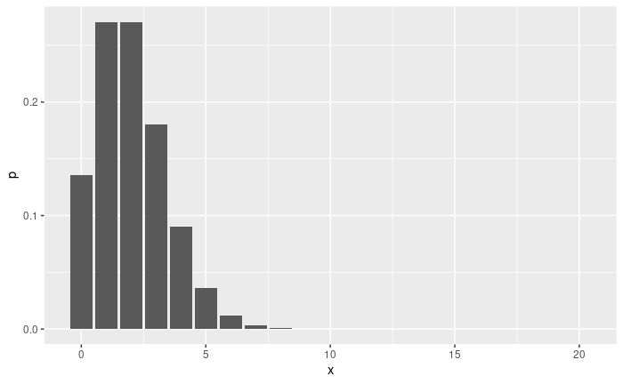

```r
dp1 <- data.frame(x = 0:20, p = dpois(x=0:20,2))
ggplot(dp1, aes(x=x, y=p)) + geom_col()
```

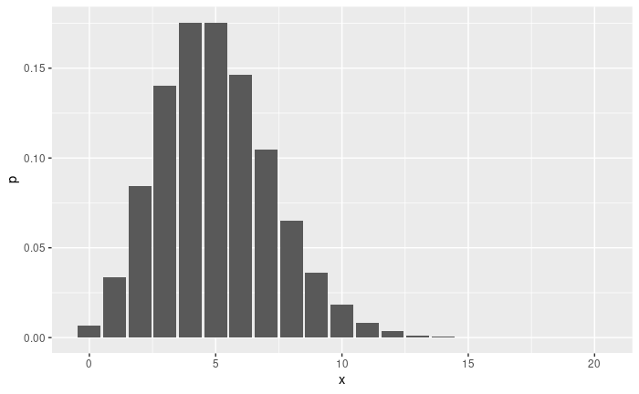

```r
dp2 <- data.frame(x = 0:20, p = dpois(x=0:20,5))
ggplot(dp2, aes(x=x, y=p)) + geom_col()
```

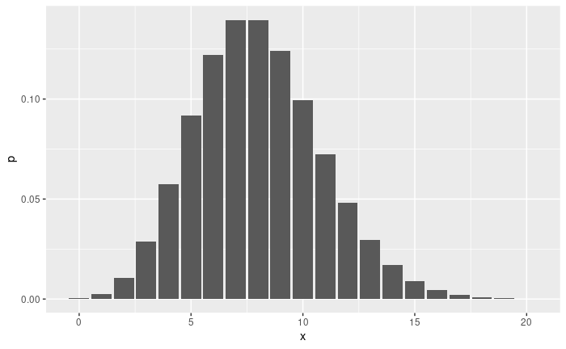

```r
dp3 <- data.frame(x = 0:20, p = dpois(x=0:20,8))
ggplot(dp3, aes(x=x, y=p)) + geom_col()
```

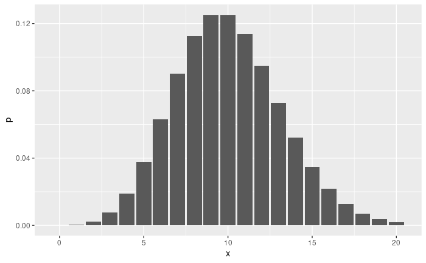

```r
dp4 <- data.frame(x = 0:20, p = dpois(x=0:20,10))
ggplot(dp4, aes(x=x, y=p)) + geom_col()
```

```r
NA
```

# Entry Exam Cheatsheet

### Binomial

```r
### Binomial Distribution
# E(X) = n * p <- attempts * success probability
# Var(X) = n * p * q <- attempts * success probability * failure probability

attempts = 10 #n
succ_prob = 0.4 #p
fail_prob = 1 - succ_prob #q

# Probability of exactly X successes - P(X = exactly something)
# Let's say exactly 4 goals so P(X = 4)
dbinom(4, size = attempts, prob = succ_prob) # <- Dbinom

# Probability of at most 5 goals - P(X <= 5)
pbinom(5, size = attempts, prob = succ_prob) # <- Pbinom

# Probability of at least 7 goals - P(X >= 7)
1 - pbinom(6, size = attempts, prob = succ_prob)

# Distribution function in a table
data.frame(x=0:attempts,p=dbinom(x=0:attempts,size = attempts, prob = succ_prob))
```

###Poisson

```r
# P ( X = k) = [e^(-lambda)  * lambda^k] / k!
lamb = 2 #just an example

# E(X) = lambda
# Var(X) = lambda

# Exactly 4 four accidents (successes) = P(X = 4)
dpois(4, lambda = lamb)

# At most 4 accidents = P(P <= 4)
ppois(4, lambda = lamb)

# At least 3 (more than 2) accidents = P(X >= 3) or P(X > 2)
1 - ppois(2, lambda = lamb)
```

Assume that X ~ Pois(4.5). Please calculate P(X > 3.25) and provide an answer rounded up to 4 digits.

```r
lamb = 4.5
ex = 3.25

1-ppois(ex, lambda = lamb)
```

[output not shown]